# Regional Variations of Female Representation of Female Representation on Highest Courts

Heewon Oh

02/12/2021

Female representation in the legal system is known to be low in most countries; however, this is even more so on the Highest Courts (i.e. Supreme Court). There is a general perception that non-Western regions have higher levels of female representation in all levels of society, including judicial systems. Many attribute this due to economic or social factors. We wanted to thus see regional variations to confirm these popular assumptions. Thus, in countries that have had female representation by 1990, we wanted to observe female representation in 2010, 20-year growth from 1990-2010, and the proportion of countries with representation in both years.

This dataset is an unbalanced panel dataset that compiles global data on female representation in the respective highest courts of each country. The data included 210 countries ranging from 1946-2020. The data was compiled by researchers from Taxes A&M, ASU, and University of Nebraska Lincoln. The representation data begins from the year the country first added a female member and reported representation up to 2013. Hence, we decided to focus on data 1990-2010. This includes the country name, year,year the first women was added, number of women added into the court, the percentage of women, and the region the country belongs to. We thus use percentage of countries that have never had female representation, percentage women in 2010, number of women, and twenty-year change, by region as our key variables.

```r
library(tidyverse)
library(dplyr)
data <-read_csv("WOHCv1.csv")

data2<-data%>%
  filter(year == 1990)%>%
  mutate(firstpct = pctwomen)

data3<-data%>%
  filter(year == 2010)%>%
  mutate(lastpct = pctwomen)

data4 <- data2 %>%
  left_join(data3, by="country")
data5 <- data4%>%
  mutate(pctchange = as.numeric(lastpct)-as.numeric(firstpct))%>%
  group_by(region.x)%>%
  summarize(regionchange = mean(pctchange,na.rm=TRUE),twentyten=mean(as.numeric(lastpct), na.rm=TRUE))
```

```r
data8 <- data3 %>%
  mutate(nowoman = if_else(yearfirstwoman == "none as of 2020", 1, 0))
data10 <- data%>%
  mutate(numberwomen=as.numeric(numwomen,na.rm=TRUE))
data9 <-data2%>%
  left_join(data3, by="country")%>%
  mutate(pctchange = as.numeric(lastpct)-as.numeric(firstpct))%>%
  left_join(data8, by="country")%>%
  left_join(data10,by="country")%>%
  group_by(region.x)%>%
  summarize(regionchange = mean(pctchange,na.rm=TRUE),twentyten=mean(as.numeric(lastpct.x), na.rm=TRUE),nowomanyet = mean(nowoman,na.rm=TRUE), numberofwomen=mean(numberwomen,na.rm=TRUE))
```

```r
library(qwraps2)
options(qwraps2_markup = "markdown")
databyregion<-data9
statstable <- as.data.frame(databyregion)
summary_statistics <-
  list(
    "Twenty-Year Change" =
      list(
        "mean (sd)" = ~qwraps2::mean_sd(regionchange, na_rm = TRUE),
        "min" = ~min(regionchange, na.rm = TRUE),
        "max" = ~max(regionchange, na.rm = TRUE)
      ),
    "2010 Representation" =
      list(
        "mean (sd)" = ~qwraps2::mean_sd(twentyten, na_rm = TRUE),
        "min" = ~min(twentyten, na.rm = TRUE),
        "max" = ~max(twentyten, na.rm = TRUE)
      ),
    "Proportion of No Woman Yet" =
      list(
        "mean (sd)" = ~qwraps2::mean_sd(nowomanyet, na_rm = TRUE),
        "min" = ~min(nowomanyet, na.rm = TRUE),
        "max" = ~max(nowomanyet, na.rm = TRUE)

      ),
      "Number of Women" =
      list(
        "mean (sd)" = ~qwraps2::mean_sd(numberofwomen, na_rm = TRUE),
        "min" = ~min(numberofwomen, na.rm = TRUE),
        "max" = ~max(numberofwomen, na.rm = TRUE)

      )

    )
summary_table(databyregion, summary_statistics)
```

|  | databyregion (N = 8) |
| --- | --- |
| **Twenty-Year Change** |  |
| mean (sd) | 10.79 ± 7.15 |
| min | 2.06516605504587 |
| max | 23.86675 |
| **2010 Representation** |  |
| mean (sd) | 15.54 ± 11.15 |
| min | 2.38810183486239 |
| max | 36.666675 |
| **Proportion of No Woman Yet** |  |
| mean (sd) | 0.13 ± 0.20 |
| min | 0 |
| max | 0.589383770591824 |
| **Number of Women** |  |
| mean (sd) | 1.09 ± 0.96 |
| min | 0.170792079207921 |
| max | 3 |

We see that there is significant standard deviations in all variables by region. Most notably, we see that the variable representing the proportion of countries with no female representation yet has the highest standard deviation in relation to its mean. This is because developing areas have greater numbers of countries with no female representation. In particular, the middle-east and north Africa region is an outlier with nearly 59% of its countries never having had female representation. So far, the results are consistent with popular belief. Note however, that we see the smallest proportional standard deviation in the 20-year change and 2010 representation variables; the first is based on comparing data from 1990 and 2010, meaning that countries that had no representation prior to 1990 are ommited.The 2010 variable also has a similar effect with 2010 as the threshold. Thus, we eliminate a lot of variance, as expected.

```r
library(plm)
reg1 <- plm(as.numeric(pctwomen)~as.numeric(numwomen)+as.factor(region)+as.numeric(yearfirstwoman),data=data, model="between", index="year")
summary(reg1)
```

```
## Oneway (individual) effect Between Model
##
## Call:
## plm(formula = as.numeric(pctwomen) ~ as.numeric(numwomen) + as.factor(region) +
##     as.numeric(yearfirstwoman), data = data, model = "between",
##     index = "year")
##
## Unbalanced Panel: n = 44, T = 85-124, N = 4609
## Observations used in estimation: 44
##
## Residuals:
##      Min.   1st Qu.    Median   3rd Qu.      Max.
## -0.831066 -0.109804  0.031999  0.134669  0.511386
##
## Coefficients:
##                                                         Estimate  Std. Error
## (Intercept)                                          -150.544590  370.089169
## as.numeric(numwomen)                                    7.093483    0.077179
## as.factor(region)East Asia & Pacific                   -9.881219    7.796809
## as.factor(region)Eastern Europe & former Soviet Asia    3.726551    5.264080
## as.factor(region)Latin America & the Caribbean         12.351466    6.421352
## as.factor(region)Middle East & North Africa            13.533077   12.397684
## as.factor(region)Scandinavia                           40.619661   21.076816
## as.factor(region)South Asia                            -0.832404    9.602793
## as.factor(region)West (not Scandinavia)                -5.110938    6.033726
## as.numeric(yearfirstwoman)                              0.073544    0.186887
##                                                      t-value Pr(>|t|)
## (Intercept)                                          -0.4068  0.68672
## as.numeric(numwomen)                                 91.9090  < 2e-16 ***
## as.factor(region)East Asia & Pacific                 -1.2673  0.21365
## as.factor(region)Eastern Europe & former Soviet Asia  0.7079  0.48382
## as.factor(region)Latin America & the Caribbean        1.9235  0.06282 .
## as.factor(region)Middle East & North Africa           1.0916  0.28269
## as.factor(region)Scandinavia                          1.9272  0.06234 .
## as.factor(region)South Asia                          -0.0867  0.93143
## as.factor(region)West (not Scandinavia)              -0.8471  0.40288
## as.numeric(yearfirstwoman)                            0.3935  0.69639
## ---
## Signif. codes:  0 '***' 0.001 '**' 0.01 '*' 0.05 '.' 0.1 ' ' 1
##
## Total Sum of Squares:    2943.1
## Residual Sum of Squares: 2.2355
## R-Squared:      0.99924
## Adj. R-Squared: 0.99904
## F-statistic: 4969.78 on 9 and 34 DF, p-value: < 2.22e-16
```

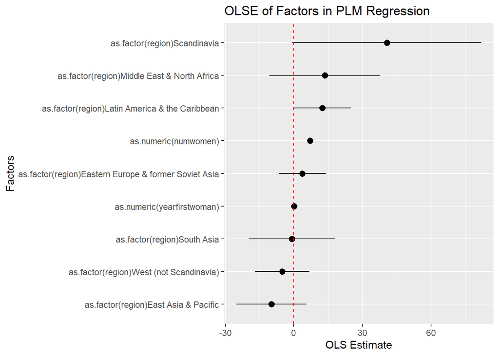

```r
library(broom)
reg1_tidy <- tidy(reg1, conf.int = TRUE)
estimates <- reg1_tidy %>%
 filter(term != "(Intercept)")
p <- ggplot(estimates, aes(x = reorder(term, estimate), y = estimate, ymin = conf.low, ymax = conf.high))
p + geom_pointrange() + coord_flip() + labs(x="", y="OLS Estimate") + geom_hline(yintercept = 0, linetype="dashed", color = "red")+labs(title = "OLSE of Factors in PLM Regression",x="Factors")
```

With permission from the professor, I used a plm function as this is an unbalanced panel dataset, which would mean that ols would be unsuitable as it would introduce bias. The dependent variable is the percent of women represented and the independent variables are the number of women, the first year woman is represented, and dummy variables for region. We do this to better understand what factors affect proportional female representation using the variables at hand.From this, we can certainly learn that the number of women is significantly related to the percentage of women, which is logical. However, none of the other variables show significance. The F-stat and the adjusted R squared are both very high, suggesting this model is good at predicting. We see that Latin America and Scanadinavia are significant at 10% significance levels. Thus, while it is probable that region may play some influence, some of the less insignificant regressors are intuitively wrong given our other results, such as the positive effect of middle east and negative of the West. Thus, we are likely missing better indicators such as gender-culture, and economic output.

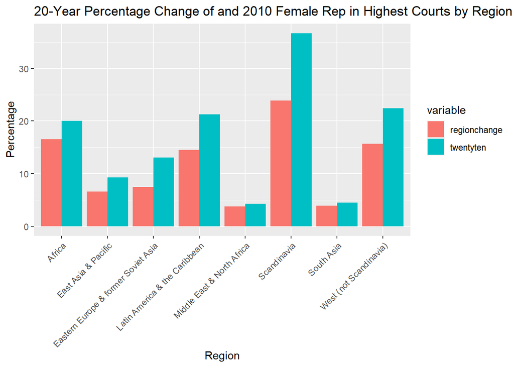

```r
data6 <- data5

library(reshape2)
data7 <-melt(data6)
ggplot(data7,aes(region.x,value,fill=variable))+
     geom_bar(stat="identity",position="dodge")+
     theme(axis.text.x = element_text(angle =45, hjust = 1))+
     labs(title = "20-Year Percentage Change of and 2010 Female Rep in Highest Courts by Region", x = "Region", y = "Percentage")
```

We decided to conduct a barchart by region to compare regional proportional change and 2010 representation. We believed this would give the most accurate visualization for the topic at hand – how does representation vary? Surprisingly, the graph fielded interesting results. While it is important to note that countries without any representation before 1990 and 2010 were ommitted for the regionchange and twentyten variables respectively, we see results that partly contradict popular belief. While Scandinavia is the leader in both categories and the Middle East and South Asia the worst-performers, we can notably see how similar Africa, Latin America and the West excluding Scandinavia are. These regions even outperform Eastern Europe and the former soviet Asia.

Conclusion: From our report, we found that regional variations definitely exist in the data, and not all of them support popular belief. The results shown in Africa and Latin America in our graph particularly, make us inquire the causes of the differences in representation. The results from these two areas suggest that perhaps the casual effect of economic development may be exaggerated in popular belief.

References: Packages used: reshape2,broom,plm,qwraps2,tidyverse,dplyr

Data and location: https://www.openicpsr.org/openicpsr/project/135801/version/V1/view https://womenonhighcourts.com/data/

Webpages: https://thatdatatho.com/easily-create-descriptive-summary-statistic-tables-r-studio/ https://stackoverflow.com/questions/15158230/barplot-with-2-variables-side-by-side